# Pixar_survey

Mustafa Telab

9/3/2020

```r
knitr::opts_chunk$set(echo = TRUE)
library(dplyr)
library(readr)
library(plyr)
library(sqldf)
```

```r
library(ggplot2)
library(tidyverse)
library(tidyr)

box_office <- read.csv('/Users/mustafatelab/Desktop/CUNY SPS MSDS/607 - Data Acquisition & Management/Week 2/Assignment/box_office.csv')
survey <- read.csv('/Users/mustafatelab/Desktop/CUNY SPS MSDS/607 - Data Acquisition & Management/Week 2/Assignment/Pixar_Survey - Favorite Pixar Film.csv')
```

The Below is an analysis conducted on a small social sample, requesting the participants to rate a selection of movies from 1-10. The results show the movie, rating, and an id designating which results came from the same participant.

The first goal is to see which movie is the most liked by my social circle.

Secondly, we will find out who is the biggest critic.

lastly, by integrating box office data, we will check for if the ratings are assiciated with the money the movies brought in.

```r
head(survey)
```

|  | Movie | Ratings | userid |
| --- | --- | --- | --- |
| 1 | Frozen | 9 | 1 |
| 2 | Up | 10 | 1 |
| 3 | Toy Story | 10 | 1 |
| 4 | Finding Nemo | 9 | 1 |
| 5 | Ratatouille | 6 | 1 |
| 6 | Monsters_ Inc. | 5 | 1 |

Not So Much: A Bug’s Life unfortunately comes in last.

```r
avg_movie_rating <- sqldf('select movie, avg(Ratings) from survey group by Movie Order by avg(Ratings) desc')
avg_movie_rating
```

| Movie | avg(Ratings) |
| --- | --- |
| Toy Story | 8.153846 |
| Finding Nemo | 8.153846 |
| Ratatouille | 7.769231 |
| Monsters_ Inc. | 7.615385 |
| Cars | 7.538462 |
| Up | 7.230769 |
| Incredibles | 6.846154 |
| Frozen | 6.769231 |
| WALL-E | 6.384615 |
| A Bug's Life | 5.307692 |

Biggest Critic: Participant number 12! (must not be a huge fan of animated films)

```r
avg_user_rating <- sqldf('select userid, avg(Ratings) from survey group by userid Order by avg(Ratings)')
avg_user_rating
```

| userid | avg(Ratings) |
| --- | --- |
| 12 | 6.3 |
| 7 | 6.4 |
| 3 | 6.5 |
| 6 | 6.5 |
| 8 | 6.5 |
| 1 | 7.0 |
| 11 | 7.0 |
| 4 | 7.1 |
| 13 | 7.3 |
| 5 | 7.6 |

[output cut: 3 more lines]

We also have box office numbers for the associated films. (USA and worldwide do not overlap)

```r
box_office
```

| movies | usa_box_office | world_box_office |
| --- | --- | --- |
| Frozen | 400738009 | 880064273 |
| Up | 293004016 | 442094918 |
| Toy Story | 222498679 | 181766759 |
| Finding Nemo | 380843261 | 559506825 |
| Ratatouille | 203445654 | 417280431 |
| Monsters_ Inc. | 289916256 | 289064814 |
| Incredibles | 261441092 | 370165621 |
| WALL-E | 223808164 | 297503696 |
| A Bug's Life | 162798565 | 200460294 |
| Cars | 244082982 | 217908885 |

Lets combine the ratings with the box office

```r
rating_box <- avg_movie_rating %>%
  left_join( box_office, by = c( 'Movie' = 'movies'), copy = FALSE)%>%
  mutate(total_gross = usa_box_office + world_box_office)

rating_box
```

| Movie | avg(Ratings) | usa_box_office | world_box_office | total_gross |
| --- | --- | --- | --- | --- |
| Toy Story | 8.153846 | 222498679 | 181766759 | 404265438 |
| Finding Nemo | 8.153846 | 380843261 | 559506825 | 940350086 |
| Ratatouille | 7.769231 | 203445654 | 417280431 | 620726085 |
| Monsters_ Inc. | 7.615385 | 289916256 | 289064814 | 578981070 |
| Cars | 7.538462 | 244082982 | 217908885 | 461991867 |
| Up | 7.230769 | 293004016 | 442094918 | 735098934 |
| Incredibles | 6.846154 | 261441092 | 370165621 | 631606713 |
| Frozen | 6.769231 | 400738009 | 880064273 | 1280802282 |
| WALL-E | 6.384615 | 223808164 | 297503696 | 521311860 |
| A Bug's Life | 5.307692 | 162798565 | 200460294 | 363258859 |

Rating VS Total$$

```r
cor(rating_box$`avg(Ratings)`, rating_box$total_gross)
```

```
## [1] 0.1451279
```

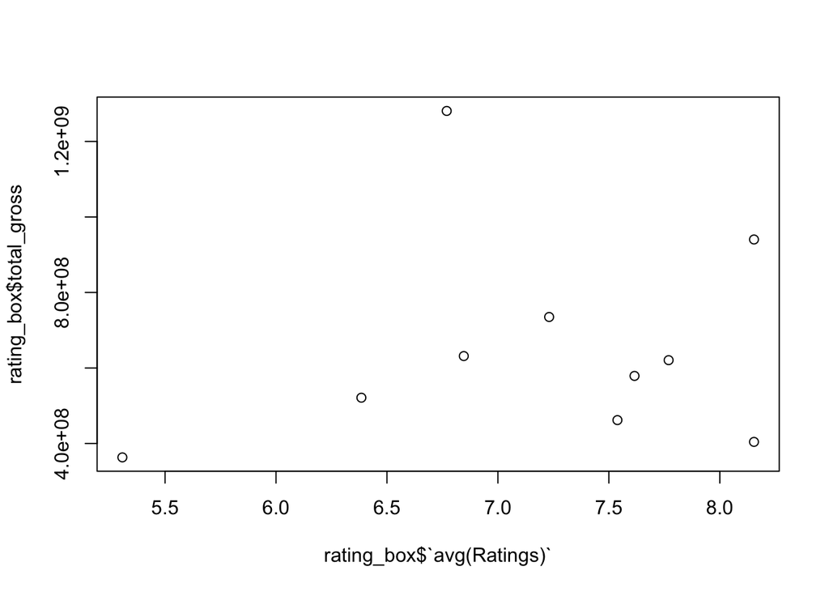

```r
plot(rating_box$`avg(Ratings)`, rating_box$total_gross)
```

Rating VS Domestic$$

```r
cor(rating_box$`avg(Ratings)`, rating_box$usa_box_office)
```

```
## [1] 0.3500506
```

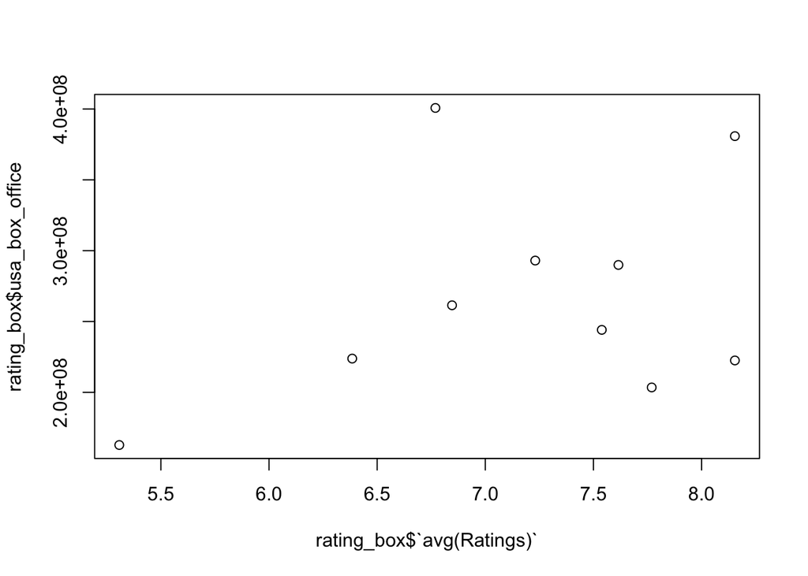

```r
plot(rating_box$`avg(Ratings)`, rating_box$usa_box_office)
```

Rating VS Foreign$$

```r
cor(rating_box$`avg(Ratings)`, rating_box$world_box_office)
```

```
## [1] 0.0652046
```

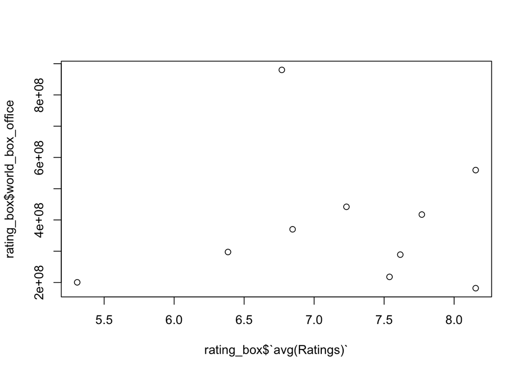

```r
plot(rating_box$`avg(Ratings)`, rating_box$world_box_office)
```

From the sample that we surveyed, there does not appear to be a strong correlation between box office gross and movie rating.

However, we do see that the more local the box office measure the higher the correlation, with domestic being the most correlated, and rest of the world being the least correlated.